# State MSM Profile: **Alabama**

### Background & Methods

In 2015-2016, researchers at Emory University partnered with colleagues at the Centers for Disease Control and Prevention (CDC) to develop methods to estimate the number of men who have sex with men (MSM) residing in each county in the United States. Using population and housing data from the [American Community Survey](https://www.census.gov/programs-surveys/acs/) and estimates from two peer-reviewed publications ([Oster et al., 2015](http://www.ncbi.nlm.nih.gov/pubmed/26115985) & [Purcell et al., 2012](http://www.ncbi.nlm.nih.gov/pubmed/23049658)), they derived an indirect estimate of MSM population sizes that took into account both the urbanicity of the county as well as its density of households with a male householder and a male same-sex partner.

The full methodology is published in the *Journal of Medical Internet Research - Public Health and Surveillance*:

> [Grey JA, Bernstein KT, Sullivan PS, Purcell DW, Chesson HW, Gift TL, Rosenberg ES. Estimating the population sizes of men who have sex with men in US states and counties using data from the American Community Survey. JMIR Public Health Surveill 2016;2(1):e14. DOI: 10.2196/publichealth.5365](http://publichealth.jmir.org/2016/1/e14/)

### Overview of MSM in Alabama

An estimated **40,600** men who have sex with men (MSM) resided in Alabama in 2013, representing 0.9% of the 4,503,084 MSM in the United States. Of the 1,754,583 adult men of Alabama, 2.3% had had sex with another man in the past 5 years, which was less than the overall percentage of adult men in the United States who were MSM (3.9%).

Most MSM in Alabama resided in counties within medium or small metropolitan areas (40.7%). Including both central and fringe counties, 40.3% resided in a large metropolitan area.

##### **Percentage of MSM by urbanicity, United States and Alabama, 2013**

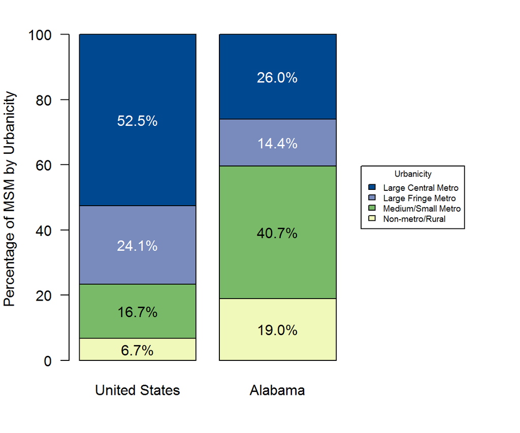

### MSM in Alabama Counties

Among counties or county-equivalent areas in Alabama, Jefferson County had the largest population of MSM at 10,540, representing 26.0% of all MSM in the state. Cleburne County had the highest percentage of MSM among adult men in Alabama at 5.5%. This was greater than the percentage for Alabama as a whole, which was 2.3% of adult men.

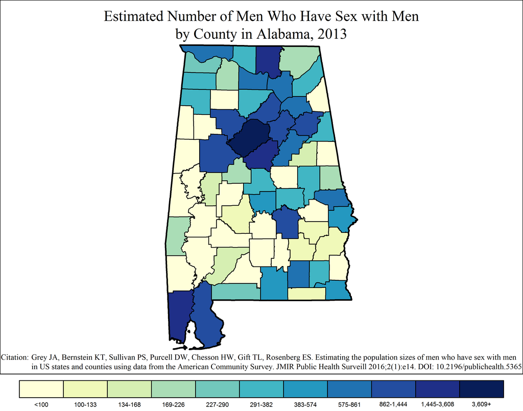

Note: Range cutpoints for the map are based on the distribution of MSM among all counties in the United States.

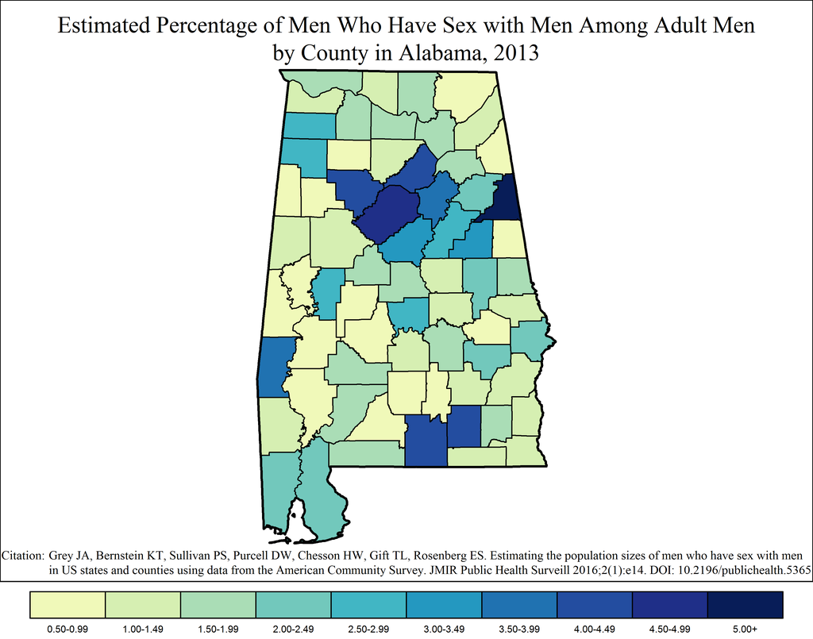

### MSM in Alabama Metropolitan Statistical Areas

#### Birmingham-Hoover Metropolitan Statistical Area

The Birmingham-Hoover MSA had the largest metropolitan population of MSM in Alabama at 16,375, or 40.3% of all MSM in the state. Of the 408,496 adult men in Birmingham-Hoover, an estimated 4.0% were MSM.

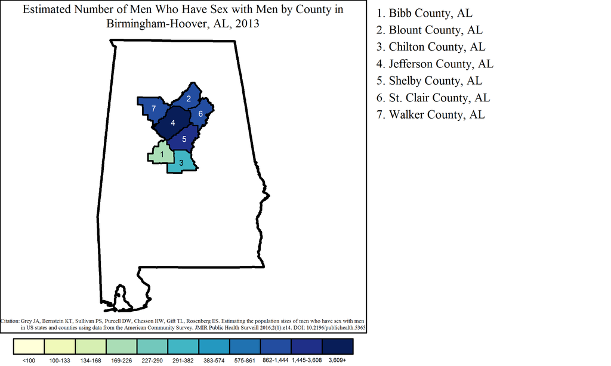

Note: Range cutpoints for the map are based on the distribution of MSM among all counties in the United States.

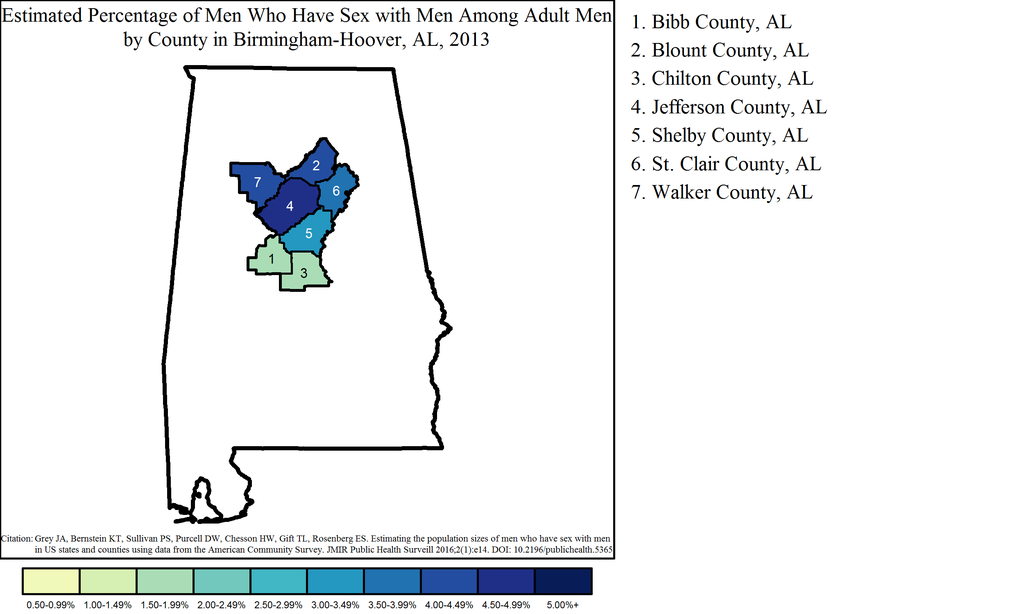

#### Mobile Metropolitan Statistical Area

The Mobile MSA had a population of 3,393 MSM, or 8.4% of all MSM in Alabama. Of the 146,239 adult men in Mobile, an estimated 2.3% were MSM.

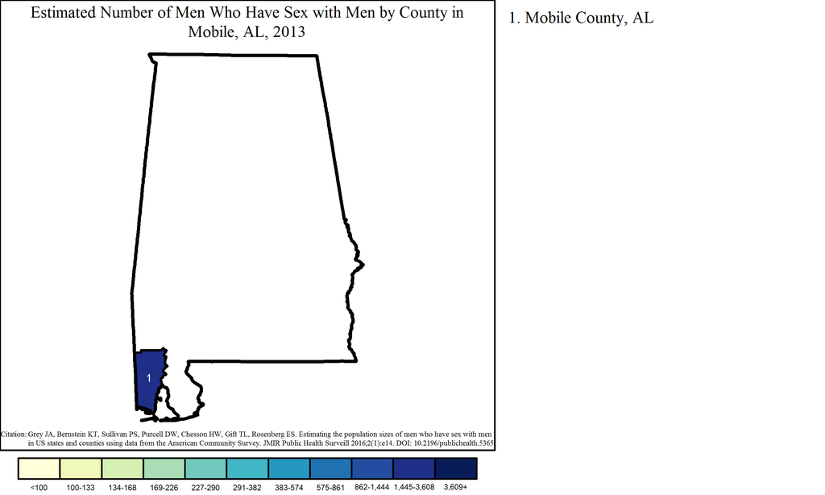

Note: Range cutpoints for the map are based on the distribution of MSM among all counties in the United States.

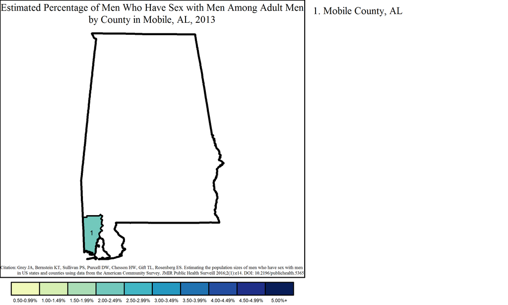

#### Huntsville Metropolitan Statistical Area

The Huntsville MSA had a population of 2,801 MSM, or 6.9% of all MSM in Alabama. Of the 158,716 adult men in Huntsville, an estimated 1.8% were MSM.

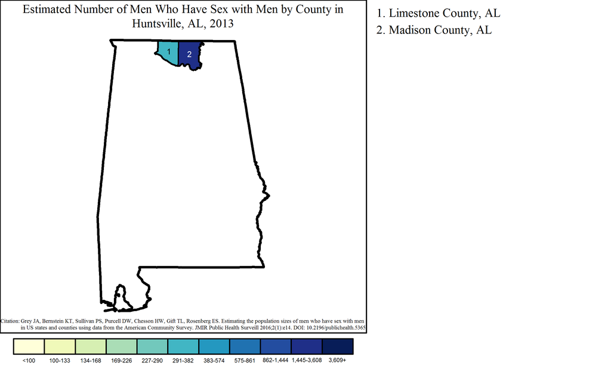

Note: Range cutpoints for the map are based on the distribution of MSM among all counties in the United States.

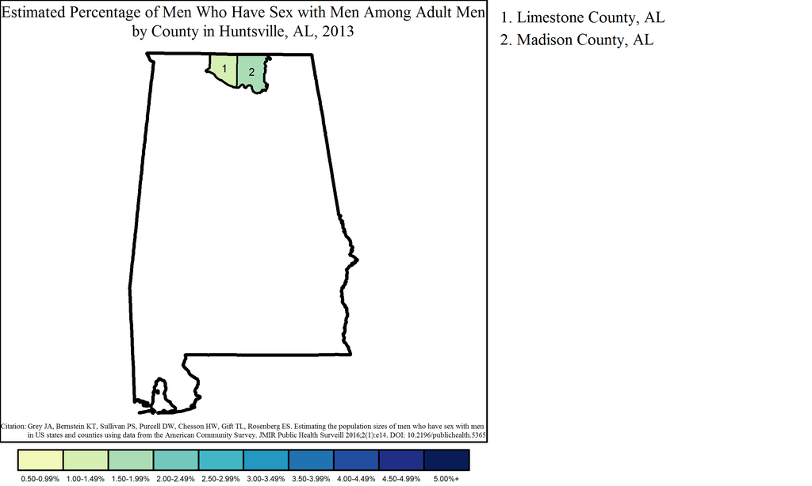

#### Montgomery Metropolitan Statistical Area

The Montgomery MSA had a population of 2,207 MSM, or 5.4% of all MSM in Alabama. Of the 133,147 adult men in Montgomery, an estimated 1.7% were MSM.

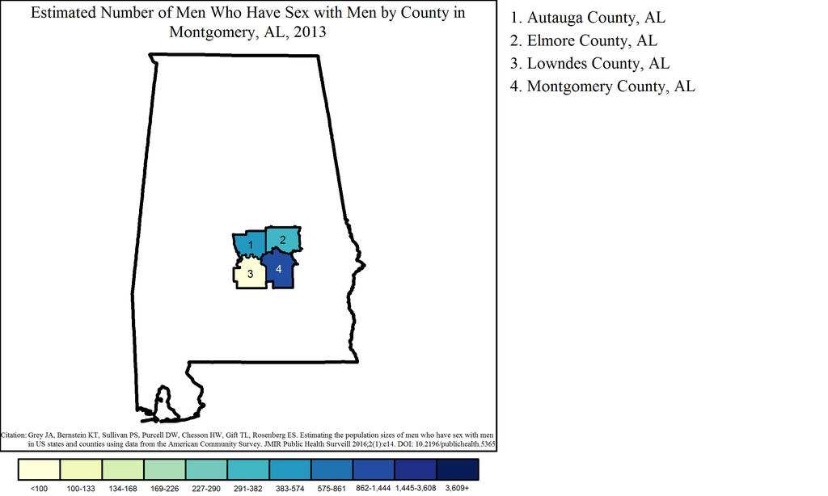

Note: Range cutpoints for the map are based on the distribution of MSM among all counties in the United States.

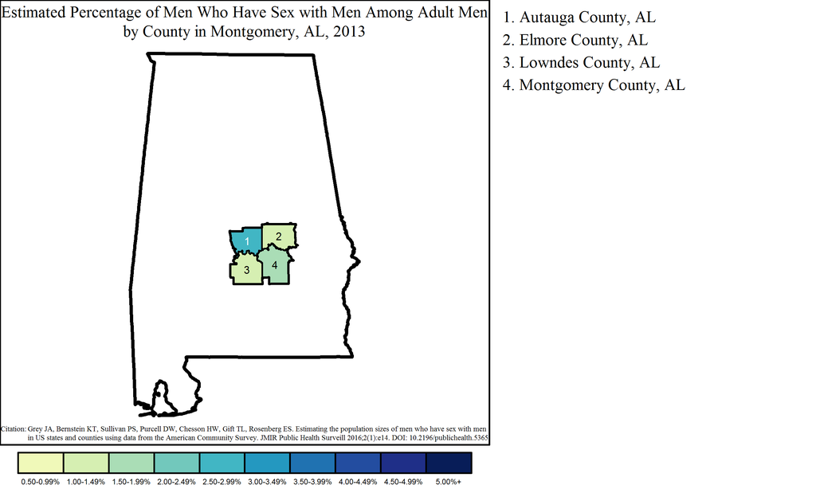

#### Daphne-Fairhope-Foley Metropolitan Statistical Area

The Daphne-Fairhope-Foley MSA had a population of 1,429 MSM, or 3.5% of all MSM in Alabama. Of the 69,724 adult men in Daphne-Fairhope-Foley, an estimated 2.0% were MSM.

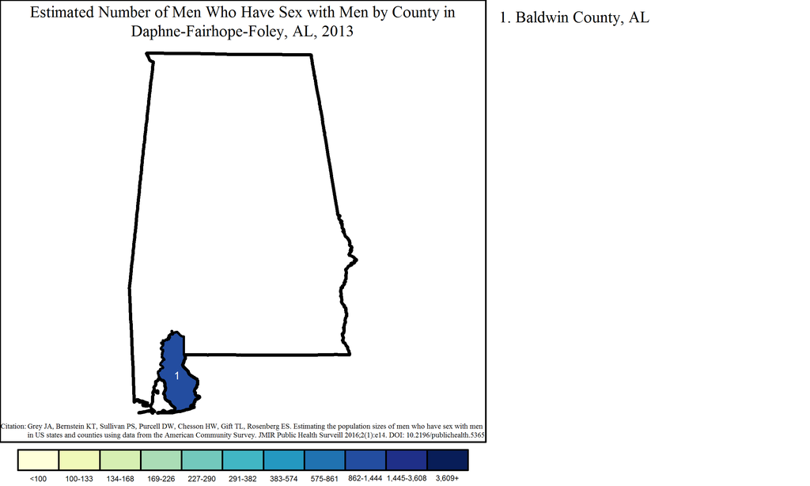

Note: Range cutpoints for the map are based on the distribution of MSM among all counties in the United States.

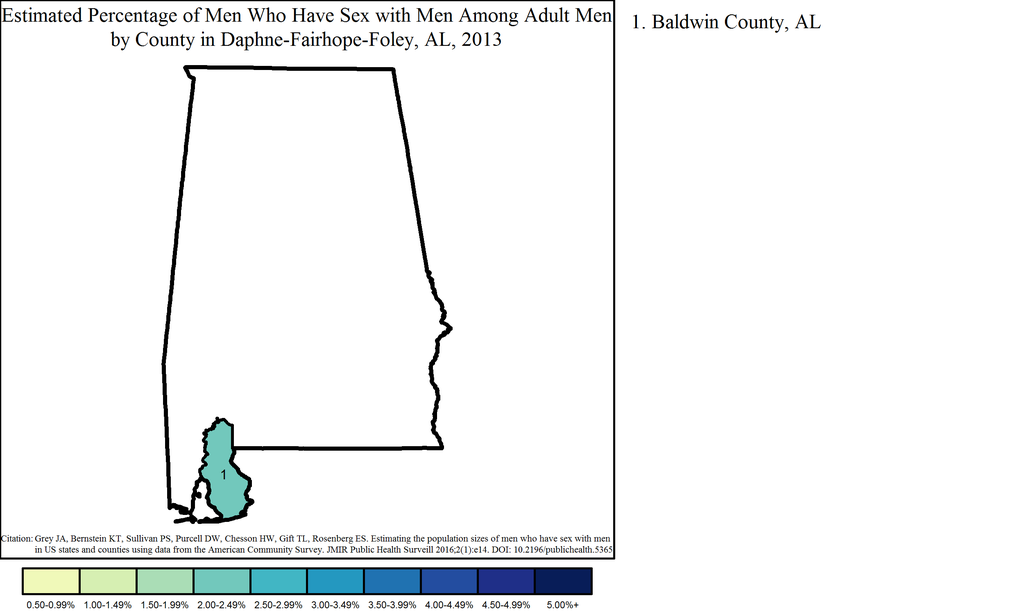

#### Tuscaloosa Metropolitan Statistical Area

The Tuscaloosa MSA had a population of 1,301 MSM, or 3.2% of all MSM in Alabama. Of the 86,406 adult men in Tuscaloosa, an estimated 1.5% were MSM.

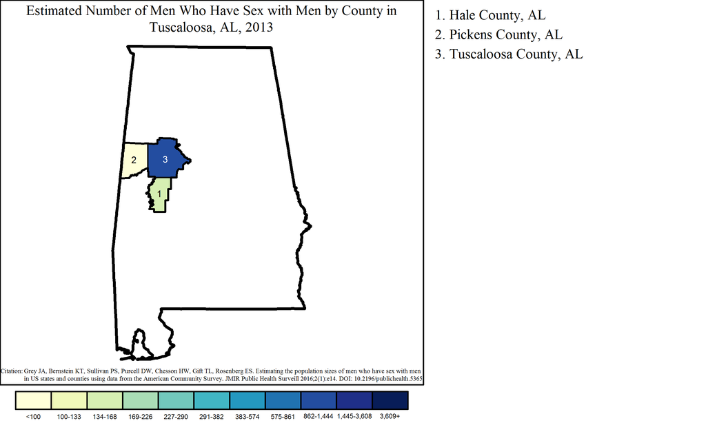

Note: Range cutpoints for the map are based on the distribution of MSM among all counties in the United States.

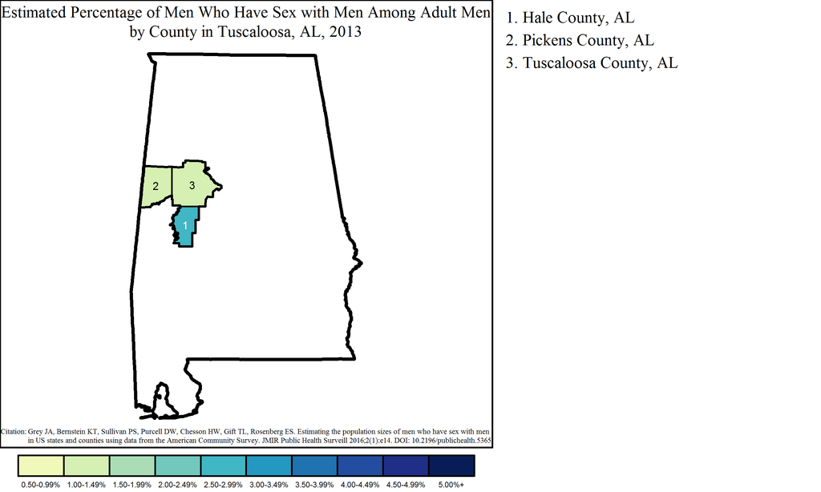

#### Anniston-Oxford-Jacksonville Metropolitan Statistical Area

The Anniston-Oxford-Jacksonville MSA had a population of 1,070 MSM, or 2.6% of all MSM in Alabama. Of the 43,018 adult men in Anniston-Oxford-Jacksonville, an estimated 2.5% were MSM.

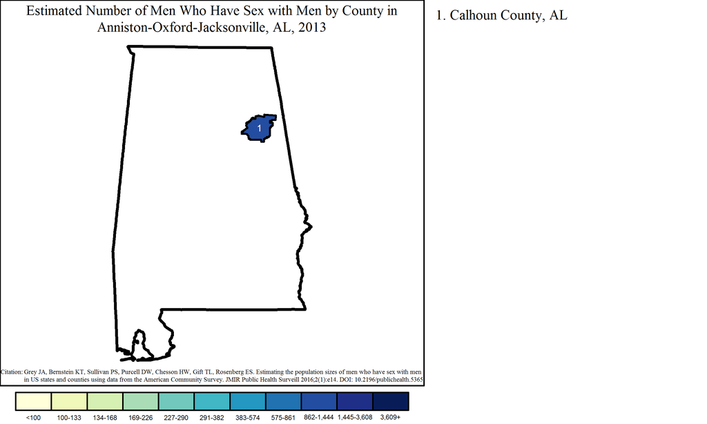

Note: Range cutpoints for the map are based on the distribution of MSM among all counties in the United States.

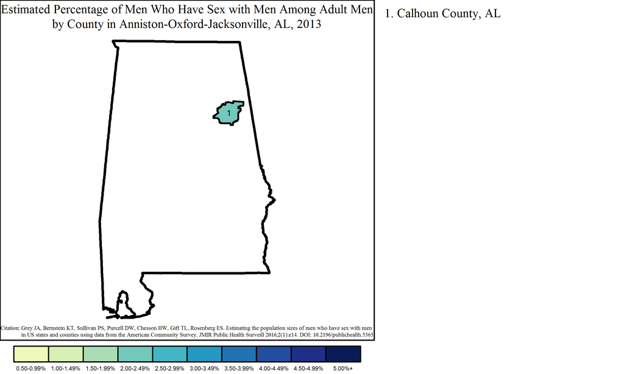

#### Decatur Metropolitan Statistical Area

The Decatur MSA had a population of 1,002 MSM, or 2.5% of all MSM in Alabama. Of the 57,127 adult men in Decatur, an estimated 1.8% were MSM.

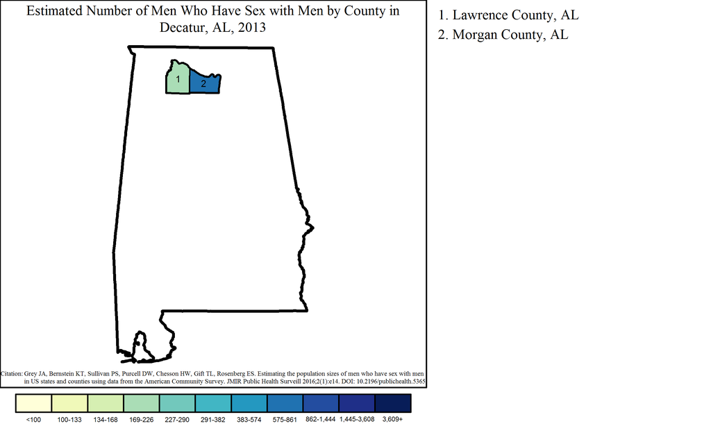

Note: Range cutpoints for the map are based on the distribution of MSM among all counties in the United States.

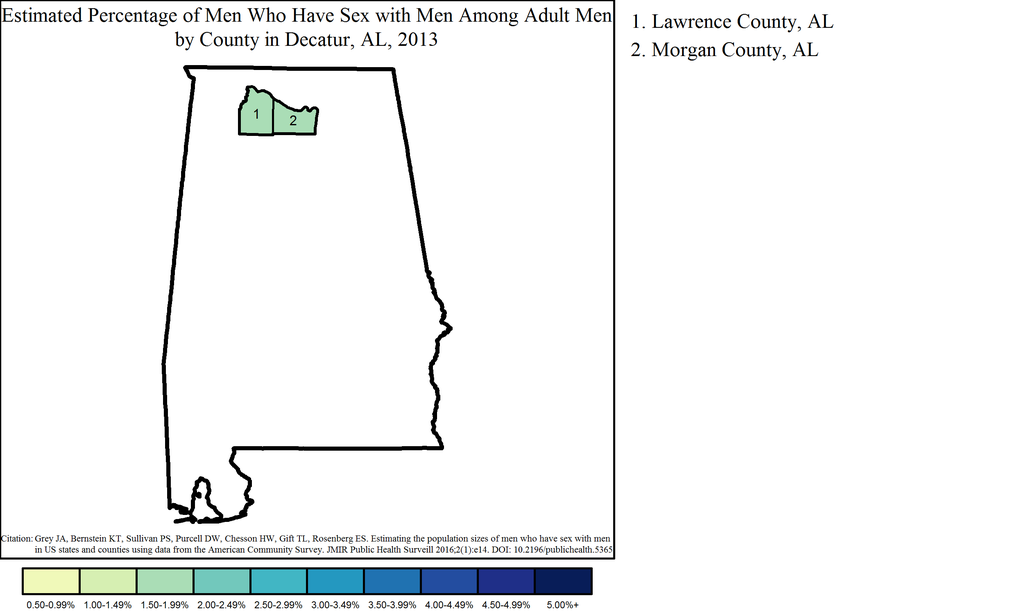

#### Florence-Muscle Shoals Metropolitan Statistical Area

The Florence-Muscle Shoals MSA had a population of 918 MSM, or 2.3% of all MSM in Alabama. Of the 54,488 adult men in Florence-Muscle Shoals, an estimated 1.7% were MSM.

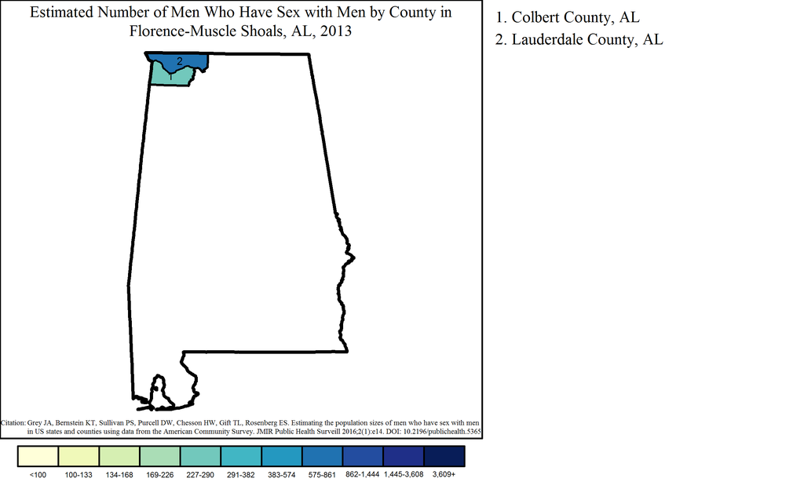

Note: Range cutpoints for the map are based on the distribution of MSM among all counties in the United States.

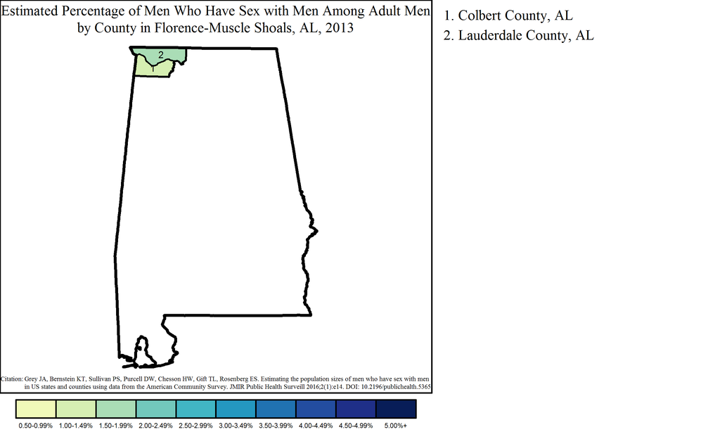

#### Auburn-Opelika Metropolitan Statistical Area

The Auburn-Opelika MSA had a population of 765 MSM, or 1.9% of all MSM in Alabama. Of the 55,081 adult men in Auburn-Opelika, an estimated 1.4% were MSM.

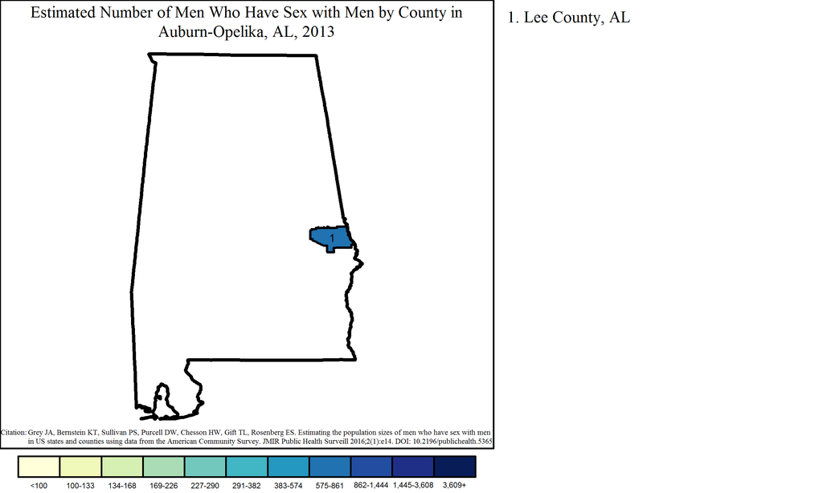

Note: Range cutpoints for the map are based on the distribution of MSM among all counties in the United States.

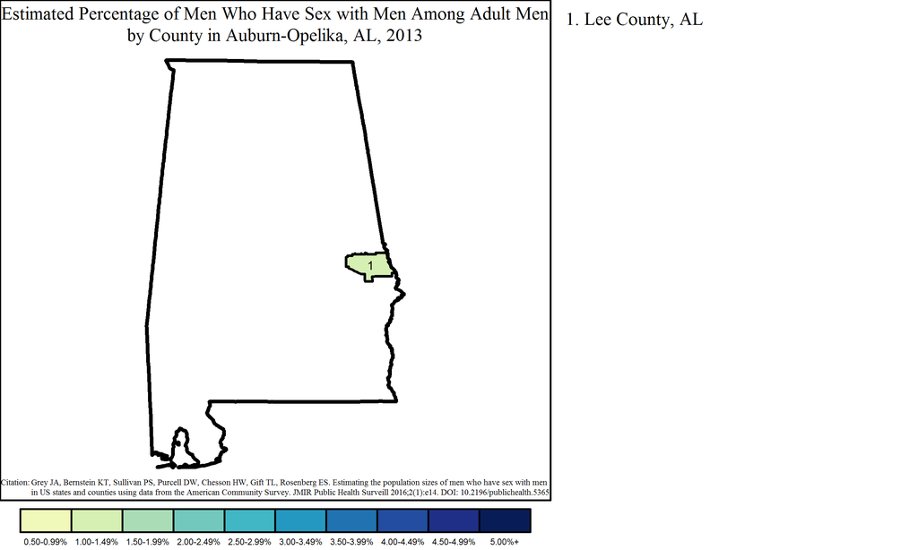

#### Dothan Metropolitan Statistical Area

The Dothan MSA had a population of 665 MSM, or 1.6% of all MSM in Alabama. Of the 52,667 adult men in Dothan, an estimated 1.3% were MSM.

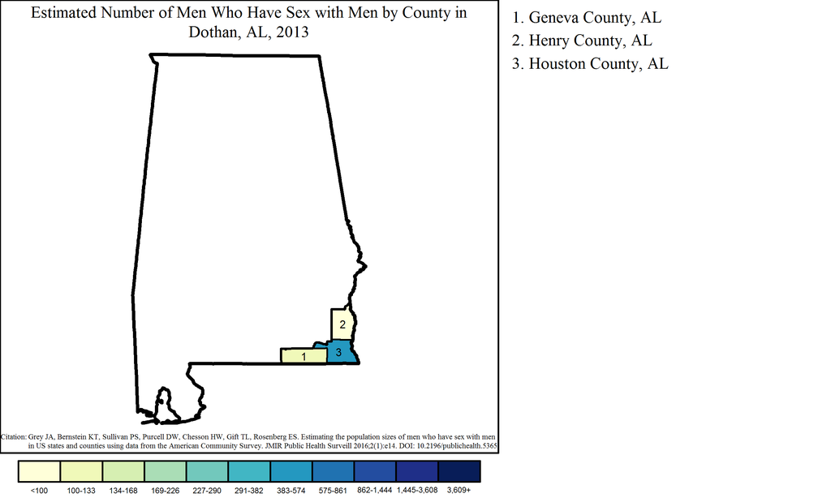

Note: Range cutpoints for the map are based on the distribution of MSM among all counties in the United States.

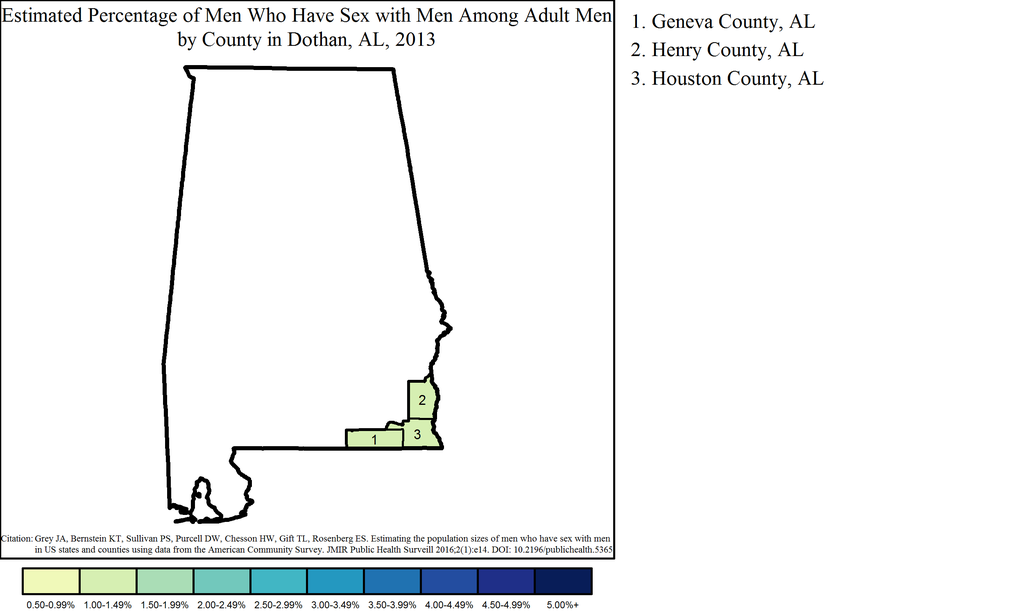

#### Gadsden Metropolitan Statistical Area

The Gadsden MSA had a population of 577 MSM, or 1.4% of all MSM in Alabama. Of the 38,227 adult men in Gadsden, an estimated 1.5% were MSM.

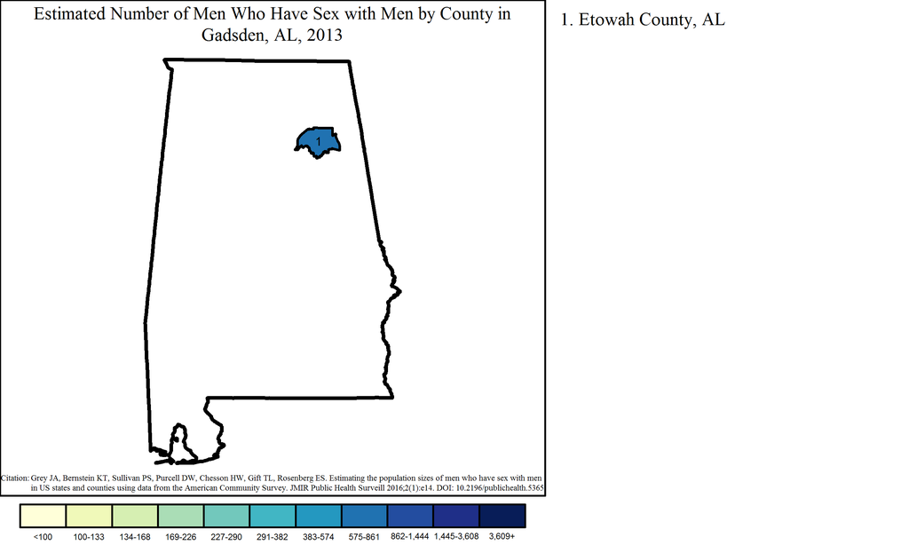

Note: Range cutpoints for the map are based on the distribution of MSM among all counties in the United States.

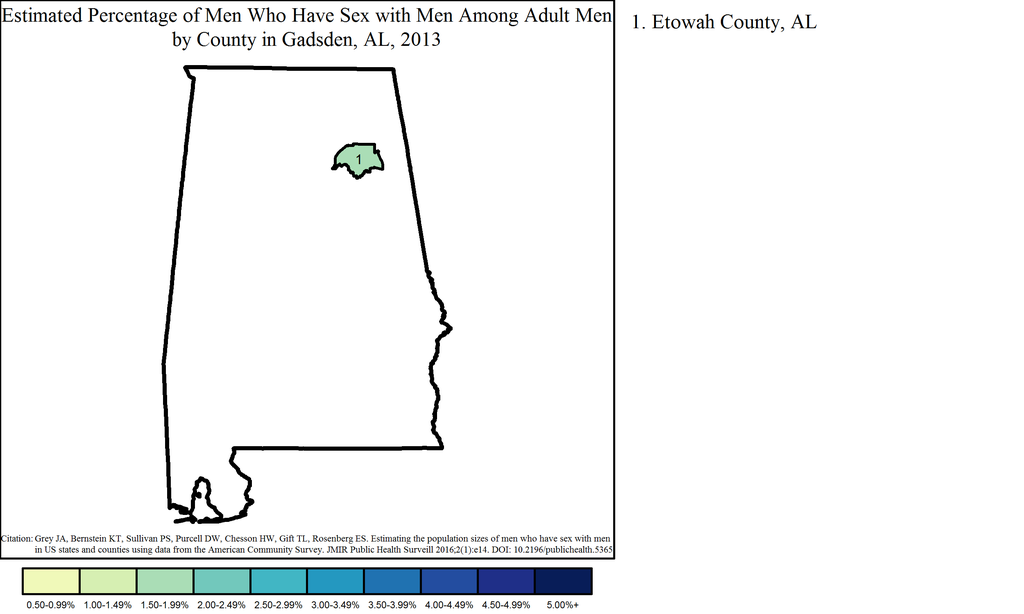

#### Columbus Metropolitan Statistical Area

The Columbus MSA overlaps two states: Alabama and Georgia. The Alabama portion of the MSA had 391 MSM, or 1.0% of all MSM in the state and 18.3% of the 2,132 MSM in the MSA. Of 19,520 adult men in the Alabama part of Columbus, 2.0% were MSM. This was greater than the overall percentage of MSM among adult men in the MSA, which was 1.9% of adult men (2,132 out of 110,539).

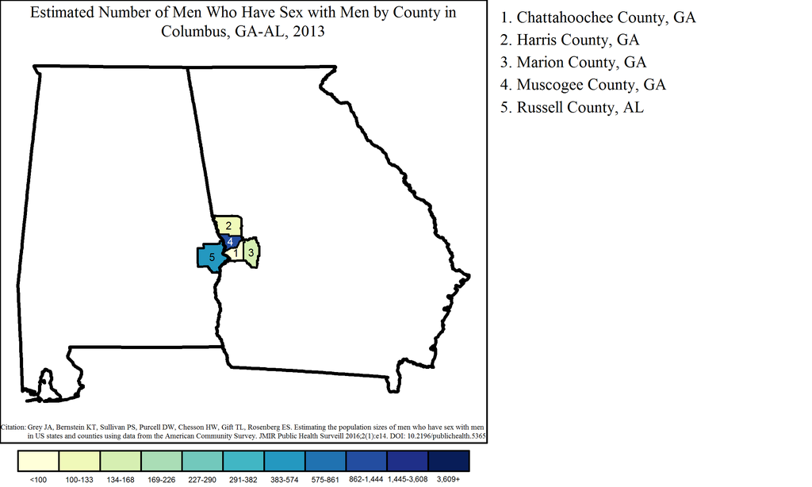

Note: Range cutpoints for the map are based on the distribution of MSM among all counties in the United States.

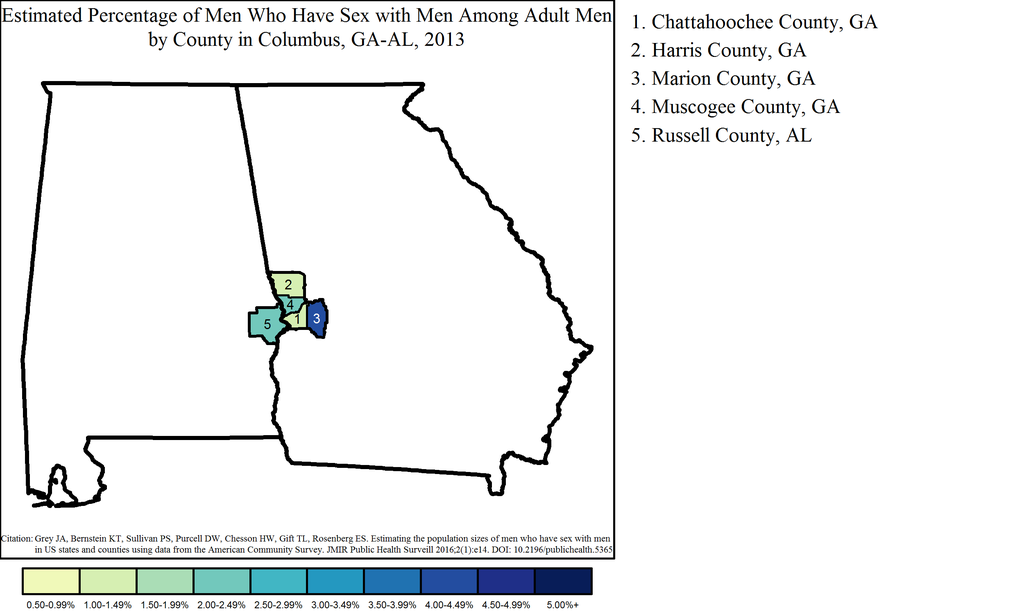